# Assignment Wind Power

# Descriptive statistics

### 1. Read the data tuno.txt into R.

```r
data <- read.delim("tuno.txt",header = TRUE, sep = " ", dec = ".")
head(data,6)
```

|  | r.day | month | day | pow.obs | ws30 | wd30 |
| --- | --- | --- | --- | --- | --- | --- |
| 1 | 1 | 1 | 1 | 243.0278 | 6.723611 | 4.0343405 |
| 2 | 2 | 1 | 2 | 2780.0137 | 4.272603 | 2.1365208 |
| 3 | 3 | 1 | 3 | 2118.6164 | 4.272603 | 1.6240318 |
| 4 | 4 | 1 | 4 | 1660.8767 | 6.541096 | 0.2269022 |
| 5 | 5 | 1 | 5 | 1872.7945 | 9.713699 | 5.3161852 |
| 6 | 6 | 1 | 6 | 3212.2603 | 8.161644 | 0.9522963 |

### 2. Make a graphical presentation of data or parts of the data, and present some summary statistics.

#### Summary statistics:

```r
summary(data[c(0,4:6)],digits = 2)
```

```
    pow.obs             ws30           wd30
 Min.   :   0.12   Min.   : 1.1   Min.   :9.5e-05
 1st Qu.: 254.16   1st Qu.: 5.8   1st Qu.:2.5e+00
 Median : 964.12   Median : 8.5   Median :4.1e+00
 Mean   :1381.20   Mean   : 9.1   Mean   :3.6e+00
 3rd Qu.:2196.58   3rd Qu.:11.2   3rd Qu.:4.9e+00
 Max.   :4681.06   Max.   :24.9   Max.   :6.3e+00
```

#### Graphical presentation:

```r
# Distribution of the power production

library(ggpubr)
```

```r
# do we in some months produce more power?
library(tidyverse)
```

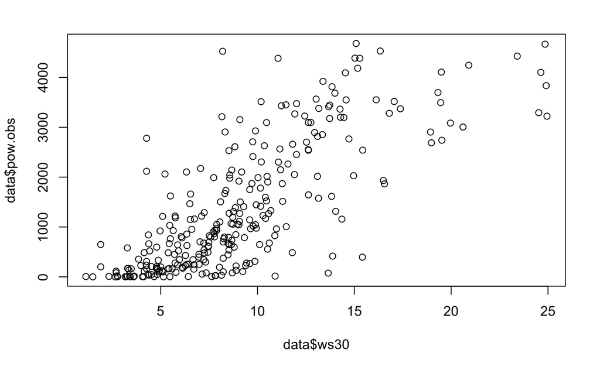

```r
#does a high wind prediction equal a high power production?
# Indeed yes!
plot(data$ws30,data$pow.obs)
```

```r
# correlation matrix with power, wind speed and wind direction:
cor(data)
```

```
              r.day       month         day     pow.obs        ws30        wd30
r.day    1.00000000  0.99502353  0.13792305 -0.15019124 -0.07063362  0.05659029
month    0.99502353  1.00000000  0.03886557 -0.14633297 -0.07159566  0.06013753
day      0.13792305  0.03886557  1.00000000 -0.05418983 -0.01030742 -0.02926142
pow.obs -0.15019124 -0.14633297 -0.05418983  1.00000000  0.76352856  0.15550796
ws30    -0.07063362 -0.07159566 -0.01030742  0.76352856  1.00000000  0.24152194
wd30     0.05659029  0.06013753 -0.02926142  0.15550796  0.24152194  1.00000000
```

#### Normalize the power production before modelling:

```r
normalize <- function(x) {
  return ((x+0.01 - min(x)) / (max(x) - min(x)+0.04))}

data$pow.obs.norm<-normalize(data$pow.obs)

head(data,6)
```

|  | r.day | month | day | pow.obs | ws30 | wd30 | pow.obs.norm |
| --- | --- | --- | --- | --- | --- | --- | --- |
| 1 | 1 | 1 | 1 | 243.0278 | 6.723611 | 4.0343405 | 0.05189396 |
| 2 | 2 | 1 | 2 | 2780.0137 | 4.272603 | 2.1365208 | 0.59387167 |
| 3 | 3 | 1 | 3 | 2118.6164 | 4.272603 | 1.6240318 | 0.45257700 |
| 4 | 4 | 1 | 4 | 1660.8767 | 6.541096 | 0.2269022 | 0.35478981 |
| 5 | 5 | 1 | 5 | 1872.7945 | 9.713699 | 5.3161852 | 0.40006193 |
| 6 | 6 | 1 | 6 | 3212.2603 | 8.161644 | 0.9522963 | 0.68621274 |

```r
NA
```

### 3. Simple models:

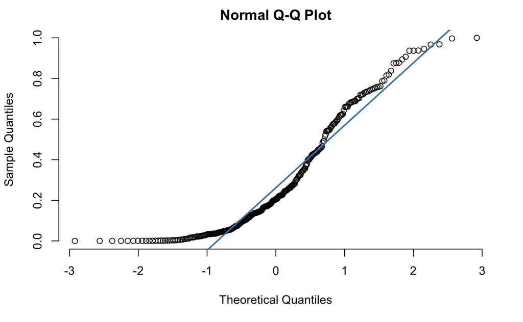

```r
data$pow.obs.norm.log<-log(data$pow.obs.norm)

qqnorm(data$pow.obs.norm, pch = 1, frame = FALSE)
qqline(data$pow.obs.norm, col = "steelblue", lwd = 2)
```

The curvature of the qq-plot indicates that a beta distribution might fit the data well. **http://onlinestatbook.com/2/advanced_graphs/q-q_plots.html

#### Fitting a beta distribution to the data.

The likelihood function for the wind data, can be defined as a sum of the log density functions
$$l(\theta)=\sum_{i=1}^{n}log(p_{\theta}(x_{i}))$$

where $p_{\theta}$ in this case is the beta density function given as:
$$f(x) = \frac{(x-a)^{p-1}(b-x)^{q-1}}{B(p,q) (b-a)^{p+q-1}}
\hspace{.3in} a \le x \le b; p, q > 0$$

where p and q are the shape parameters, a and b are the lower and upper bounds, respectively, of the distribution, and B(p,q) is the beta function. The beta function has the formula
$$B(\alpha,\beta) = \int_{0}^{1} {t^{\alpha-1}(1-t)^{\beta-1}dt}$$
The likelihood function can easily be implemented in R:

```r
Beta.likelihood=function(shape1, shape2){ -sum(dbeta(x=data$pow.obs.norm,shape1=shape1, shape2=shape2, log=TRUE))}
```

Now the optimal value of the two shape parameters must be found. This can be done using profile likelihood, the profile likelihood is defined as: Let $(\theta, \delta)$ be the full parameter and $\theta$ the parameter of interest. Given the joint likelihood $L(\theta, \delta)$ the profile likelihood of $\theta$ is
$$L(\theta)=max_{\delta}L(\theta, \delta)$$
Where the maximation is performed at fixed value of $\theta$ .

```r
#Profile likelihood for shape1
shape1=seq(0.35, 0.68,by=0.001)
shape2=seq(0.8, 1.6,by=0.01)


lp.shape1= function(shape1){
  ## Function for inner optimization:
  fun.tmp<- function(shape1, shape2){
    Beta.likelihood(shape1,shape2)
  }
  # Find the profile likelihood
  optimise(fun.tmp,c(0.1,10), shape1=shape1)$objective
}

(opt.shape1=optimise(lp.shape1, c(0.1,10))$minimum)
```

```
[1] 0.5051217
```

```r
#Profile likelihood for shape2

lp.shape2= function(shape2){
  ## Function for inner optimization:
  fun.tmp<- function(shape1, shape2){
    Beta.likelihood(shape1,shape2)
  }
  # Find the profile likelihood
  optimise(fun.tmp,c(0.1,10), shape2=shape2)$objective
}

(opt.shape2=optimise(lp.shape2, c(0.1,10))$minimum)
```

```
[1] 1.147125
```

This means, that the MLE for the two shape parameters are $shape1=0.5051217$ and $shape2=1.147125$.

```r
# Profile likelihoods:
lp.shape1.plot= sapply(shape1, lp.shape1)
lp.shape2.plot= sapply(shape2, lp.shape2)

par(mfrow=c(2,1), mar=c(3.3,3.3,1,1),mgp=c(2,0.7,0))
plot(shape1,exp(-lp.shape1.plot), type="l", xlab="Profile Likelihood Shape 1")
lines(c(-2,10),exp(-qchisq(0.95,df=1)/2)*c(1,1),col=2)
```

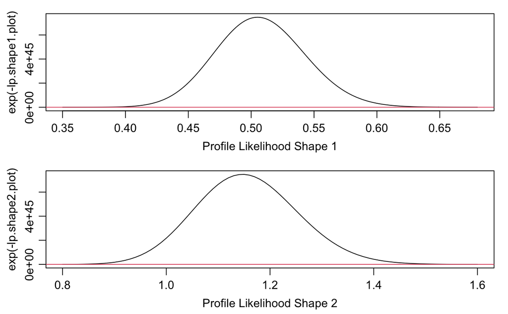

```r
plot(shape2,exp(-lp.shape2.plot), type="l", xlab="Profile Likelihood Shape 2")
lines(c(-2,10),exp(-qchisq(0.95,df=1)/2)*c(1,1),col=2)
```

Plot distribution of power.obs and the optimal fit for beta distribution.

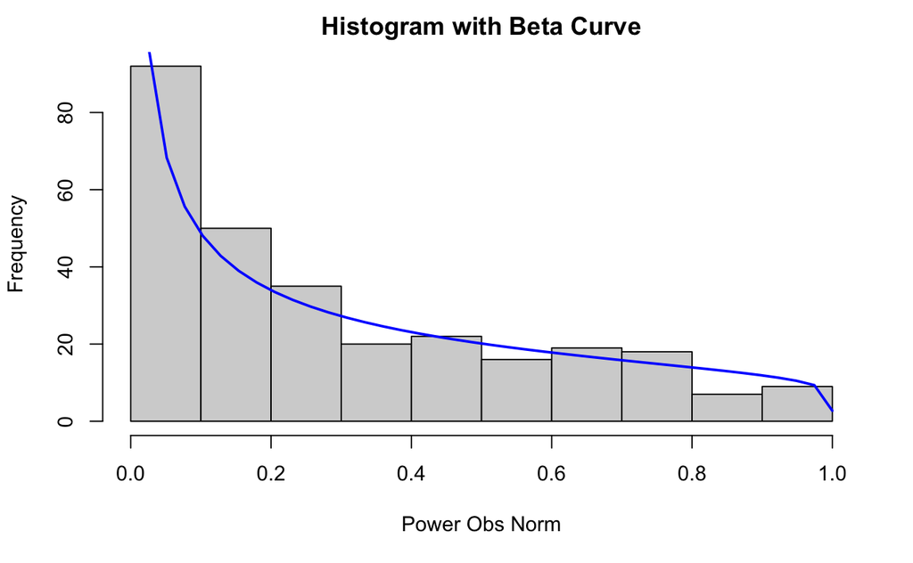

```r
# Add a Beta Curve
x <- data$pow.obs.norm
h<-hist(x, xlab="Power Obs Norm",
   main="Histogram with Beta Curve")
xfit<-seq(min(x),max(x),length=40)
yfit<-dbeta(xfit,opt.shape1,opt.shape2)
yfit <- yfit*diff(h$mids[1:2])*length(x)
lines(xfit, yfit, col="blue", lwd=2)
```

AIC is calculated using the formula:
$$AIC=2k-2ln(\hat{L})$$
where L is the maximum value for the likelihood function for the model.

```r
# Maximum value of the likelihood function for the model
(AIC.beta =2*2-2*(-Beta.likelihood(opt.shape1,opt.shape2)))
```

```
[1] -207.2545
```

#### Fitting a gamma distribution to the data.

The density function for a gamma distribution is:
$$f(x) = \frac{(\frac{x-\mu}{\beta})^{\gamma - 1}\exp{(-\frac{x-\mu}
{\beta}})} {\beta\Gamma(\gamma)} \hspace{.2in} x \ge \mu; \gamma,
\beta > 0$$

```r
Gamma.likelihood=function(shape, rate){ -sum(dgamma(x=data$pow.obs.norm,shape=shape, rate=rate, log=TRUE))}
```

Now the optimal value of the two shape parameters must be found. This can be done using profile likelihood.

```r
#Profile likelihood for shape
shape=seq(0.1, 0.9,by=0.001)
rate=seq(0.1, 0.9,by=0.01)


lp.gamma.shape= function(shape){
  ## Function for inner optimization:
  fun.tmp<- function(shape, rate){
    Gamma.likelihood(shape,rate)
  }
  # Find the profile likelihood
  optimise(fun.tmp,c(0.1,10), shape=shape)$objective
}

(opt.gamma.shape=optimise(lp.gamma.shape, c(0.1,10))$minimum)
```

```
[1] 0.6830784
```

Find the optimal value for the rate parameter.

```r
#Profile likelihood for rate

lp.gamma.rate= function(rate){
  ## Function for inner optimization:
  fun.tmp<- function(shape, rate){
    Gamma.likelihood(shape,rate)
  }
  # Find the profile likelihood
  optimise(fun.tmp,c(0.1,10), rate=rate)$objective
}

(opt.gamma.rate=optimise(lp.gamma.rate, c(0.1,10))$minimum)
```

```
[1] 2.315206
```

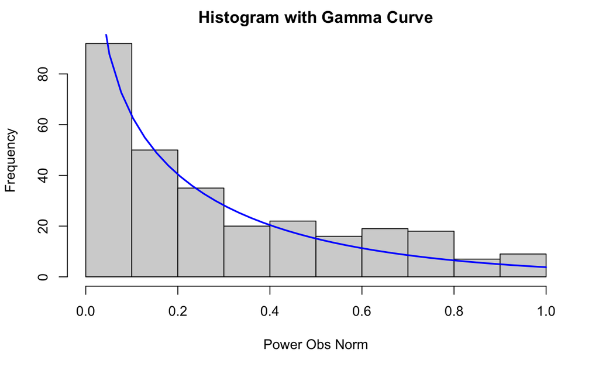

```r
# Add a Gamma Curve
x <- data$pow.obs.norm
h<-hist(x, xlab="Power Obs Norm",
   main="Histogram with Gamma Curve")
xfit<-seq(min(x),max(x),length=40)
yfit<-dgamma(xfit,opt.gamma.shape,opt.gamma.rate)
yfit <- yfit*diff(h$mids[1:2])*length(x)
lines(xfit, yfit, col="blue", lwd=2)
```

Calculating AIC for the gamma fit.

```r
# Maximum value of the likelihood function for the model
k = 2 #Number of parameters
(AIC.gamma =2*k-2*(-Gamma.likelihood(opt.gamma.shape,opt.gamma.rate)))
```

```
[1] -155.3455
```

#### Fitting a log-normal distribution to the data.

```r
LogNormal.likelihood=function(meanlog, sdlog){ -sum(dlnorm(x=data$pow.obs.norm,meanlog=meanlog, sdlog=sdlog, log=TRUE))}
```

Profile likelihood functions for the log-normal distribution.

```r
#Profile likelihood for meanlog
meanlog=seq(0.1, 0.9,by=0.001)
sdlog=seq(0.1, 0.9,by=0.01)


lp.LogNormal.meanlog= function(meanlog){
  ## Function for inner optimization:
  fun.tmp<- function(meanlog, sdlog){
    LogNormal.likelihood(meanlog,sdlog)
  }
  # Find the profile likelihood
  optimise(fun.tmp,c(0.1,10), meanlog=meanlog)$objective
}

(opt.LogNormal.meanlog=optimise(lp.LogNormal.meanlog, c(0.1,10))$minimum)
```

```
[1] 0.1000548
```

Find the optimal value for sdlog.

```r
#Profile likelihood for sdlog
lp.LogNormal.sdlog= function(sdlog){
  ## Function for inner optimization:
  fun.tmp<- function(meanlog, sdlog){
    LogNormal.likelihood(meanlog,sdlog)
  }
  # Find the profile likelihood
  optimise(fun.tmp,c(0.1,10), sdlog=sdlog)$objective
}

(opt.LogNormal.sdlog=optimise(lp.LogNormal.sdlog, c(0.1,10))$minimum)
```

```
[1] 2.964543
```

Plot distribution of power.obs and the optimal fit for log-normal distribution.

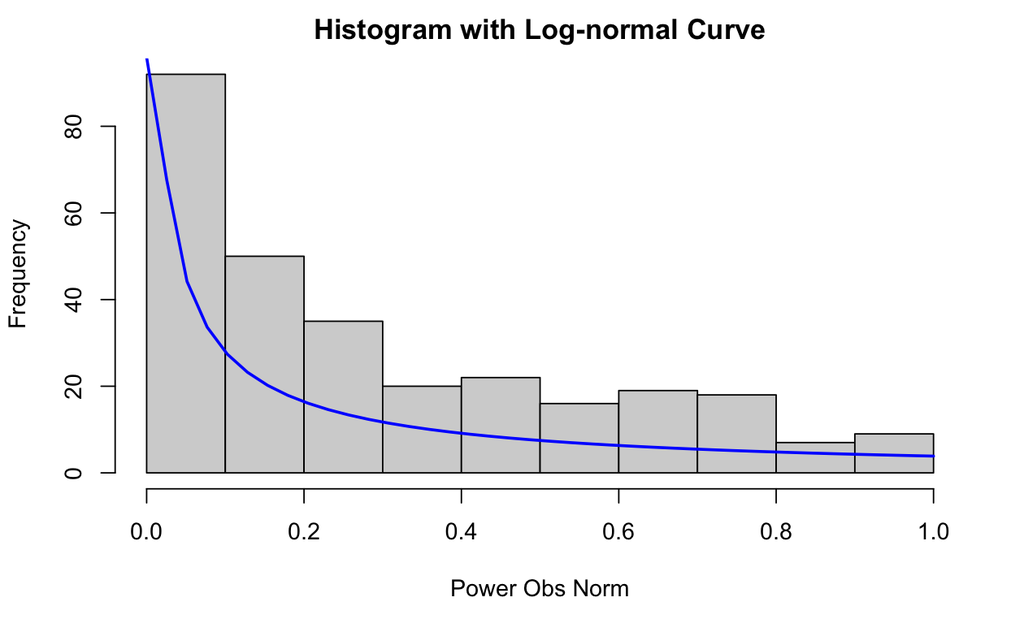

```r
# Add a Log-normal Curve
x <- data$pow.obs.norm
h<-hist(x, xlab="Power Obs Norm",
   main="Histogram with Log-normal Curve")
xfit<-seq(min(x),max(x),length=40)
yfit<-dlnorm(xfit,opt.LogNormal.meanlog,opt.LogNormal.sdlog)
yfit <- yfit*diff(h$mids[1:2])*length(x)
lines(xfit, yfit, col="blue", lwd=2)
```

Calculate AIC for log-normal distribution.

```r
# Maximum value of the likelihood function for the model
k=2
(AIC.LogNormal =2*k-2*(-LogNormal.likelihood(opt.LogNormal.meanlog,opt.LogNormal.sdlog)))
```

```
[1] 232.8163
```

#### Fit transformations

##### Box Cox

Box Cox transfomation
$$Y_{\lambda}=\frac{y^{\lambda}-1}{\lambda}$$

```r
#library(MASS)
lambda <- seq(-0.5,0.5,by=0.01)
boxcox.lambda=boxcox(lm(data$pow.obs.norm~1),lambda=lambda)

## box-cox transformation
bc.trans <- function(lambda,y){
    y.l <- (y^lambda-1)/lambda

    if(lambda==0){y.l <- log(y)}
    return(y.l)}

## profile likelihood for lambda
lp.lambda <- function(lambda,y){
    n <- length(y)
    y.l <- bc.trans(lambda ,y)
    sigmasq <- 1/n * sum((y.l-mean(y.l))^2)
    -n/2 * log(sigmasq) + (lambda-1)*sum(log(y))}


lambda <- seq(-0.5,0.5,by=0.01)

(opt.lambda=optimize(lp.lambda,c(-2,2),y=data$pow.obs,maximum=TRUE))
```

[output not shown]

```r
par(mfrow=c(1,2))
qqnorm(bc.trans(opt.lambda$maximum,data$pow.obs.norm),main="Distribution after boxcox transformation")
qqline(bc.trans(opt.lambda$maximum,data$pow.obs.norm))
qqnorm(data$pow.obs.norm, pch = 1, frame = TRUE, main="Distribution before transformation")
qqline(data$pow.obs.norm, col = "steelblue")
```

[output not shown]

##### Transformation 1

```r
trans1 <- function(lambda,y){
    y.l <- 1/lambda*log((y^lambda)/(1-y^lambda))
    return(y.l)}

## profile likelihood for lambda
lp.lambda1 <- function(lambda,y){
    n <- length(y)
    y.l <- trans1(lambda ,y)
    sigmasq <- 1/n * sum((y.l-mean(y.l))^2)
    -n/2 * log(sigmasq) + (lambda-1)*sum(log(y))}

lambda <- seq(0,2,by=0.01)

(opt.lambda1=optimize(lp.lambda1,c(0,5),y=data$pow.obs.norm,maximum=TRUE))
```

```
$maximum
[1] 0.3591506

$objective
[1] -50.03049
```